# MDMA/Psychadelics multi-level meta analysis

Author

Nicklas Hafiz

Published

June 27, 2024

```
- The library is already synchronized with the lockfile.
```

# Introduction

The analysis follows the chapter [Fitting Three-Level Meta-Analysis Models in R](https://bookdown.org/MathiasHarrer/Doing_Meta_Analysis_in_R/multilevel-ma.html#multilevel-R) from the book [Doing Meta-Analysis in R](https://bookdown.org/MathiasHarrer/Doing_Meta_Analysis_in_R/), Harrer et al. (2021).

We used R version 4.2.0 (R Core Team 2022a) and the following R packages: dmetar v. 0.1.0 (Harrer et al. 2019), extrafont v. 0.19 (Chang 2023), ggbrace v. 0.1.0 (Huber, n.d.), ggtext v. 0.1.2 (Wilke and Wiernik 2022), grid v. 4.2.0 (R Core Team 2022b), here v. 1.0.1 (Müller 2020), knitr v. 1.45 (Xie 2014, 2015, 2023), metafor v. 4.4.0 (Viechtbauer 2010), psych v. 2.3.12 (William Revelle 2023), renv v. 1.0.3 (Ushey and Wickham 2023), rmarkdown v. 2.25 (Xie, Allaire, and Grolemund 2018; Xie, Dervieux, and Riederer 2020; Allaire et al. 2023), rstatix v. 0.7.2 (Kassambara 2023), tidyverse v. 2.0.0 (Wickham et al. 2019).

# Main analysis

Because some studies provide multiple values we use a three-level Meta-Analysis Model. The nested random effect gets assigned to the grouping variable “study”. This means we allow the random intercept to vary across different studys. To obtain the estimated effect sizes for our two `drugType` levels we removed the intercept, as described in the documentation of the [metafor Package](https://www.metafor-project.org/doku.php/tips:models_with_or_without_intercept). Test statistics and confidence intervals for the fixed effects use a t-distribution. The test of moderators checks the assumption that $\mu_{mdma} = \mu_{psych} = 0$, so we get a test for an overall effect of the variable `drugType`.

To compare both `drugType` levels we defined a contrast, testing if $\mu_{mdma} - \mu_{psych} = 0$ (Wald-Type Test), see `?anova.rma`.

$I^2$ tells us how much heterogeneity is due to differences within studies (level 2), and how much is due to between study-differences (level 3). So it answers the question if the effect sizes from the same study are more similar than effect sizes from multiple studies.

# Results

**Attention**

**Descriptives**

Summary statistics for the MDMA attention effects

|  | vars | n | mean | sd | min | max | range | se |
| --- | --- | --- | --- | --- | --- | --- | --- | --- |
| N | 1 | 11 | 32.000 | 23.017 | 14.000 | 61.000 | 47.000 | 6.940 |
| es | 2 | 11 | -0.548 | 0.880 | -2.204 | 0.925 | 3.130 | 0.265 |
| se_es | 3 | 11 | 0.350 | 0.156 | 0.181 | 0.673 | 0.492 | 0.047 |

Summary statistics for the Psychedelic attention effects

|  | vars | n | mean | sd | min | max | range | se |
| --- | --- | --- | --- | --- | --- | --- | --- | --- |
| N | 1 | 6 | 13.667 | 6.861 | 8.000 | 22.000 | 14.000 | 2.801 |
| es | 2 | 6 | -2.371 | 2.129 | -5.867 | -0.610 | 5.256 | 0.869 |
| se_es | 3 | 6 | 0.591 | 0.312 | 0.298 | 1.151 | 0.853 | 0.127 |

**Model**

```
Multivariate Meta-Analysis Model (k = 17; method: REML)

  logLik  Deviance       AIC       BIC      AICc
-24.1839   48.3678   56.3678   59.2000   60.3678

Variance Components:

            estim    sqrt  nlvls  fixed       factor
sigma^2.1  1.0464  1.0230     10     no        Study
sigma^2.2  0.4710  0.6863     17     no  Study/es.id

Test for Residual Heterogeneity:
QE(df = 15) = 95.2297, p-val < .0001

Test of Moderators (coefficients 1:2):
F(df1 = 2, df2 = 8) = 7.8132, p-val = 0.0131

Model Results:

                     estimate      se     tval  df    pval    ci.lb    ci.ub
drugTypemdma          -0.5932  0.5302  -1.1190   8  0.2956  -1.8158   0.6293
drugTypepsychedelic   -2.3043  0.6078  -3.7913   8  0.0053  -3.7058  -0.9028

drugTypemdma
drugTypepsychedelic  **

---
Signif. codes:  0 '***' 0.001 '**' 0.01 '*' 0.05 '.' 0.1 ' ' 1
```

**Contrast**

```
                                       hyp  estimate        se      tval df
1: -drugTypemdma + drugTypepsychedelic = 0 -1.711037 0.8065259 -2.121491  8
         pval     ci.lb     ci.ub
1: 0.06667027 -3.570889 0.1488145
```

**\(I^2\)**

```
        % of total variance    I2
Level 1            5.856657   ---
Level 2           29.220284 29.22
Level 3           64.923059 64.92
Total I2: 94.14%
```

**Plot**

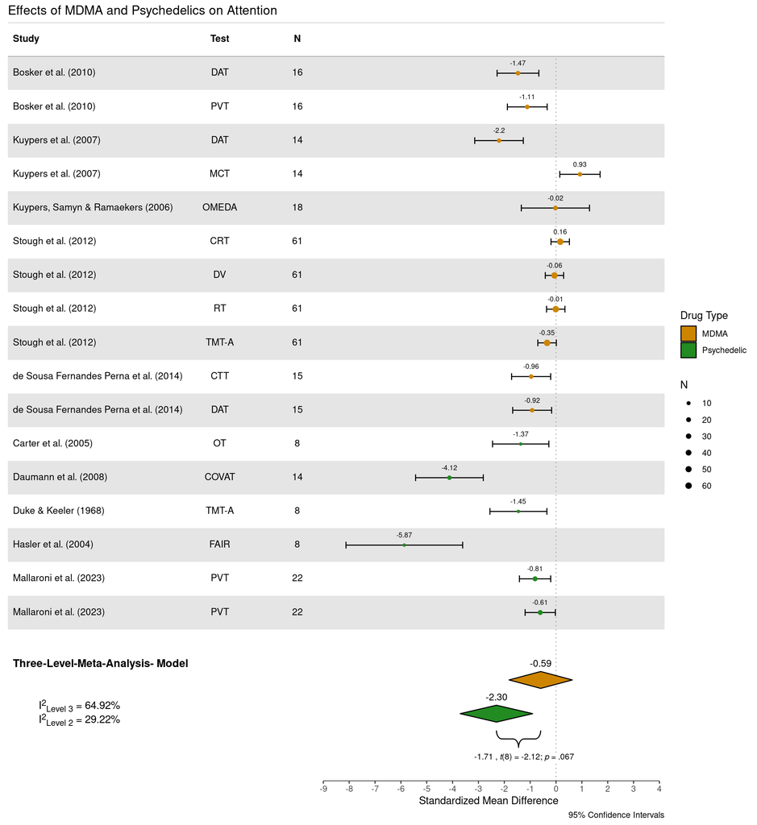

**Executive**

**Descriptives**

Summary statistics for the MDMA executive effects

|  | vars | n | mean | sd | min | max | range | se |
| --- | --- | --- | --- | --- | --- | --- | --- | --- |
| N | 1 | 10 | 20.500 | 14.339 | 13.000 | 61.000 | 48.000 | 4.534 |
| es | 2 | 10 | -0.126 | 0.456 | -0.743 | 0.665 | 1.408 | 0.144 |
| se_es | 3 | 10 | 0.342 | 0.059 | 0.182 | 0.394 | 0.212 | 0.019 |

Summary statistics for the Psychedelic executive effects

|  | vars | n | mean | sd | min | max | range | se |
| --- | --- | --- | --- | --- | --- | --- | --- | --- |
| N | 1 | 9 | 20.000 | 5.362 | 8.000 | 25.000 | 17.000 | 1.787 |
| es | 2 | 9 | -1.260 | 0.984 | -3.554 | -0.349 | 3.205 | 0.328 |
| se_es | 3 | 9 | 0.438 | 0.157 | 0.285 | 0.737 | 0.452 | 0.052 |

**Model**

```
Multivariate Meta-Analysis Model (k = 19; method: REML)

  logLik  Deviance       AIC       BIC      AICc
-17.4770   34.9541   42.9541   46.2869   46.2874

Variance Components:

            estim    sqrt  nlvls  fixed       factor
sigma^2.1  0.3126  0.5591     12     no        Study
sigma^2.2  0.0768  0.2772     19     no  Study/es.id

Test for Residual Heterogeneity:
QE(df = 17) = 52.5513, p-val < .0001

Test of Moderators (coefficients 1:2):
F(df1 = 2, df2 = 10) = 7.5524, p-val = 0.0100

Model Results:

                     estimate      se     tval  df    pval    ci.lb    ci.ub
drugTypemdma          -0.0957  0.2585  -0.3702  10  0.7190  -0.6718   0.4804
drugTypepsychedelic   -1.2204  0.3154  -3.8688  10  0.0031  -1.9233  -0.5175

drugTypemdma
drugTypepsychedelic  **

---
Signif. codes:  0 '***' 0.001 '**' 0.01 '*' 0.05 '.' 0.1 ' ' 1
```

**Contrast**

```
                                       hyp  estimate        se      tval df
1: -drugTypemdma + drugTypepsychedelic = 0 -1.124694 0.4078643 -2.757519 10
         pval     ci.lb      ci.ub
1: 0.02021568 -2.033472 -0.2159154
```

**\(I^2\)**

```
        % of total variance    I2
Level 1            23.48408   ---
Level 2            15.09965  15.1
Level 3            61.41627 61.42
Total I2: 76.52%
```

**Plot**

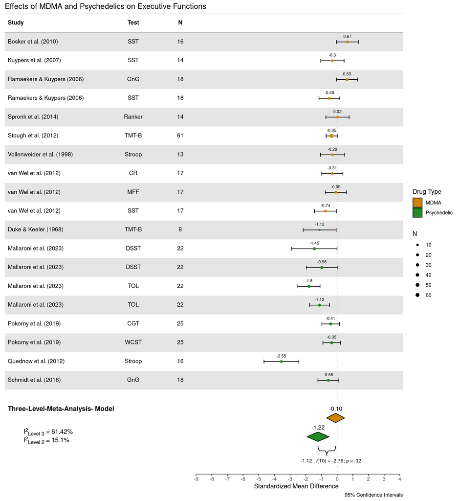

**Memory**

**Descriptives**

Summary statistics for the MDMA memory effects

|  | vars | n | mean | sd | min | max | range | se |
| --- | --- | --- | --- | --- | --- | --- | --- | --- |
| N | 1 | 22 | 21.909 | 16.068 | 12.000 | 61.000 | 49.000 | 3.426 |
| es | 2 | 22 | -1.064 | 1.259 | -3.528 | 2.335 | 5.863 | 0.269 |
| se_es | 3 | 22 | 0.395 | 0.109 | 0.182 | 0.673 | 0.491 | 0.023 |

Summary statistics for the Psychedelic memory effects

|  | vars | n | mean | sd | min | max | range | se |
| --- | --- | --- | --- | --- | --- | --- | --- | --- |
| N | 1 | 6 | 20.333 | 4.926 | 12.000 | 25.000 | 13.000 | 2.011 |
| es | 2 | 6 | -0.815 | 0.523 | -1.385 | 0.154 | 1.539 | 0.214 |
| se_es | 3 | 6 | 0.355 | 0.053 | 0.292 | 0.433 | 0.142 | 0.022 |

**Model**

```
Multivariate Meta-Analysis Model (k = 28; method: REML)

  logLik  Deviance       AIC       BIC      AICc
-40.2633   80.5266   88.5266   93.5589   90.4313

Variance Components:

            estim    sqrt  nlvls  fixed       factor
sigma^2.1  0.0171  0.1308     16     no        Study
sigma^2.2  1.0900  1.0440     28     no  Study/es.id

Test for Residual Heterogeneity:
QE(df = 26) = 231.0240, p-val < .0001

Test of Moderators (coefficients 1:2):
F(df1 = 2, df2 = 14) = 11.0264, p-val = 0.0013

Model Results:

                     estimate      se     tval  df    pval    ci.lb    ci.ub
drugTypemdma          -1.0568  0.2432  -4.3459  14  0.0007  -1.5783  -0.5352
drugTypepsychedelic   -0.8089  0.4546  -1.7793  14  0.0969  -1.7839   0.1662

drugTypemdma         ***
drugTypepsychedelic    .

---
Signif. codes:  0 '***' 0.001 '**' 0.01 '*' 0.05 '.' 0.1 ' ' 1
```

**Contrast**

```
                                       hyp  estimate        se     tval df
1: -drugTypemdma + drugTypepsychedelic = 0 0.2478831 0.5155617 0.480802 14
        pval      ci.lb    ci.ub
1: 0.6380842 -0.8578867 1.353653
```

**\(I^2\)**

```
        % of total variance    I2
Level 1            9.778865   ---
Level 2           88.827826 88.83
Level 3            1.393309  1.39
Total I2: 90.22%
```

**Plot**

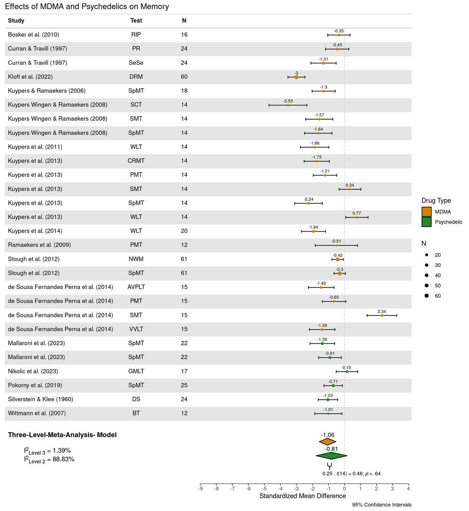

**Microdosing**

**Descriptives**

Summary statistics for the microdosing effects

|  | vars | n | mean | sd | min | max | range | se |
| --- | --- | --- | --- | --- | --- | --- | --- | --- |
| N | 1 | 6 | 29.333 | 5.715 | 20.000 | 34.000 | 14.000 | 2.333 |
| es | 2 | 6 | 0.279 | 1.299 | -1.131 | 2.404 | 3.535 | 0.530 |
| se_es | 3 | 6 | 0.275 | 0.033 | 0.247 | 0.318 | 0.071 | 0.014 |

**Model**

```
Multivariate Meta-Analysis Model (k = 6; method: REML)

  logLik  Deviance       AIC       BIC      AICc
 -8.0214   16.0428   22.0428   20.8711   46.0428

Variance Components:

            estim    sqrt  nlvls  fixed       factor
sigma^2.1  0.7596  0.8715      3     no        Study
sigma^2.2  0.9572  0.9783      6     no  Study/es.id

Test for Heterogeneity:
Q(df = 5) = 101.8893, p-val < .0001

Model Results:

estimate      se    tval  df    pval    ci.lb   ci.ub
  0.3657  0.6680  0.5474   2  0.6390  -2.5085  3.2398

---
Signif. codes:  0 '***' 0.001 '**' 0.01 '*' 0.05 '.' 0.1 ' ' 1
```

**\(I^2\)**

```
        % of total variance    I2
Level 1            4.120053   ---
Level 2           53.457661 53.46
Level 3           42.422286 42.42
Total I2: 95.88%
```

**Plot**

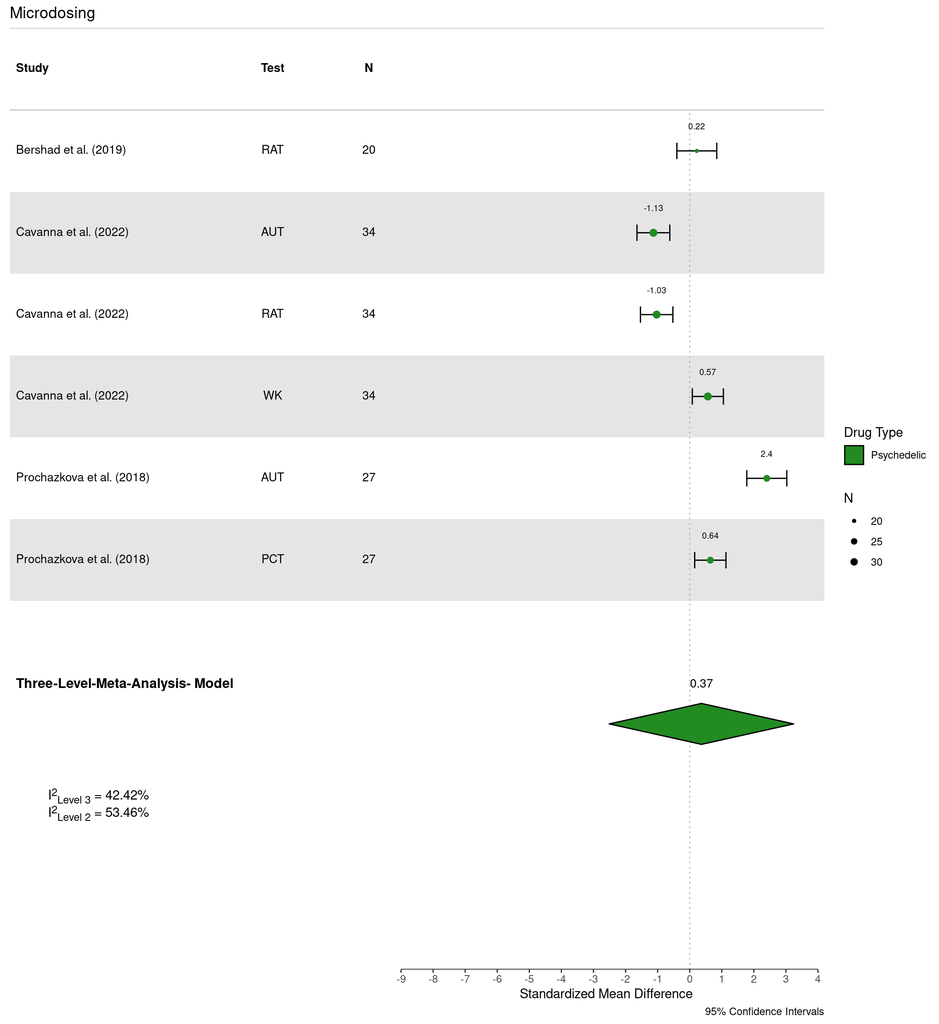

# Interpretation

# Sensitivity Analyses

In some cases redundant predictors get dropped because there are not enough cases with one of the predictors (e.g., sensitivity_psilocybin only inlcudes psychedelics).

## Results

**Attention**

**Speed**

```
$sensitivity_speed

Multivariate Meta-Analysis Model (k = 8; method: REML)

  logLik  Deviance       AIC       BIC      AICc
 -5.8971   11.7942   19.7942   18.9612   59.7942

Variance Components:

            estim    sqrt  nlvls  fixed       factor
sigma^2.1  1.7442  1.3207      5     no        Study
sigma^2.2  0.0000  0.0000      8     no  Study/es.id

Test for Residual Heterogeneity:
QE(df = 6) = 25.5765, p-val = 0.0003

Test of Moderators (coefficients 1:2):
F(df1 = 2, df2 = 3) = 3.6428, p-val = 0.1575

Model Results:

                     estimate      se     tval  df    pval    ci.lb   ci.ub
drugTypemdma          -1.1125  0.9544  -1.1657   3  0.3280  -4.1496  1.9247
drugTypepsychedelic   -1.9874  0.8164  -2.4345   3  0.0930  -4.5855  0.6106  .

---
Signif. codes:  0 '***' 0.001 '**' 0.01 '*' 0.05 '.' 0.1 ' ' 1
```

```
$sensitivity_speed
                                       hyp   estimate       se       tval df
1: -drugTypemdma + drugTypepsychedelic = 0 -0.8749798 1.255886 -0.6967029  3
        pval     ci.lb    ci.ub
1: 0.5361203 -4.871771 3.121811
```

**Accuracy**

```
$sensitivity_accuracy

Multivariate Meta-Analysis Model (k = 5; method: REML)

  logLik  Deviance       AIC       BIC      AICc
 -6.6550   13.3099   21.3099   17.7044   61.3099

Variance Components:

            estim    sqrt  nlvls  fixed       factor
sigma^2.1  0.0000  0.0001      4     no        Study
sigma^2.2  4.3607  2.0882      5     no  Study/es.id

Test for Residual Heterogeneity:
QE(df = 3) = 37.8558, p-val < .0001

Test of Moderators (coefficients 1:2):
F(df1 = 2, df2 = 2) = 2.3089, p-val = 0.3022

Model Results:

                     estimate      se     tval  df    pval     ci.lb   ci.ub
drugTypemdma          -0.4333  1.2433  -0.3485   2  0.7607   -5.7829  4.9162
drugTypepsychedelic   -3.3953  1.6012  -2.1205   2  0.1681  -10.2847  3.4941

---
Signif. codes:  0 '***' 0.001 '**' 0.01 '*' 0.05 '.' 0.1 ' ' 1
```

```
$sensitivity_accuracy
                                       hyp  estimate       se     tval df
1: -drugTypemdma + drugTypepsychedelic = 0 -2.961936 2.027223 -1.46108  2
        pval     ci.lb    ci.ub
1: 0.2814629 -11.68437 5.760502
```

**Highest Weight**

```
$sensitivity_highestWeight

Multivariate Meta-Analysis Model (k = 11; method: REML)

  logLik  Deviance       AIC       BIC      AICc
-15.9295   31.8589   39.8589   40.6478   49.8589

Variance Components:

            estim    sqrt  nlvls  fixed       factor
sigma^2.1  0.0000  0.0001      8     no        Study
sigma^2.2  1.4912  1.2211     11     no  Study/es.id

Test for Residual Heterogeneity:
QE(df = 9) = 54.2723, p-val < .0001

Test of Moderators (coefficients 1:2):
F(df1 = 2, df2 = 6) = 9.8530, p-val = 0.0127

Model Results:

                     estimate      se     tval  df    pval    ci.lb    ci.ub
drugTypemdma          -0.8335  0.4920  -1.6943   6  0.1412  -2.0373   0.3703
drugTypepsychedelic   -2.9158  0.7106  -4.1031   6  0.0063  -4.6547  -1.1769

drugTypemdma
drugTypepsychedelic  **

---
Signif. codes:  0 '***' 0.001 '**' 0.01 '*' 0.05 '.' 0.1 ' ' 1
```

```
$sensitivity_highestWeight
                                       hyp  estimate       se     tval df
1: -drugTypemdma + drugTypepsychedelic = 0 -2.082302 0.864302 -2.40923  6
         pval     ci.lb      ci.ub
1: 0.05262907 -4.197173 0.03256891
```

**Psilocybin**

```
$sensitivity_psilocybin

Multivariate Meta-Analysis Model (k = 4; method: REML)

  logLik  Deviance       AIC       BIC      AICc
 -6.6538   13.3076   19.3076   16.6035   43.3076

Variance Components:

            estim    sqrt  nlvls  fixed       factor
sigma^2.1  1.9374  1.3919      4     no        Study
sigma^2.2  1.9374  1.3919      4     no  Study/es.id

Test for Heterogeneity:
Q(df = 3) = 18.2863, p-val = 0.0004

Model Results:

estimate      se     tval  df    pval    ci.lb   ci.ub
 -2.1757  1.0415  -2.0890   3  0.1279  -5.4903  1.1389

---
Signif. codes:  0 '***' 0.001 '**' 0.01 '*' 0.05 '.' 0.1 ' ' 1
```

**High Quality**

```
$sensitivity_highQuality

Multivariate Meta-Analysis Model (k = 13; method: REML)

  logLik  Deviance       AIC       BIC      AICc
-10.5031   21.0062   29.0062   30.5978   35.6729

Variance Components:

            estim    sqrt  nlvls  fixed       factor
sigma^2.1  1.9085  1.3815      7     no        Study
sigma^2.2  0.0032  0.0567     13     no  Study/es.id

Test for Residual Heterogeneity:
QE(df = 11) = 48.8065, p-val < .0001

Test of Moderators (coefficients 1:2):
F(df1 = 2, df2 = 5) = 3.4069, p-val = 0.1165

Model Results:

                     estimate      se     tval  df    pval    ci.lb   ci.ub
drugTypemdma          -0.5958  0.7160  -0.8321   5  0.4432  -2.4363  1.2447
drugTypepsychedelic   -2.1950  0.8872  -2.4742   5  0.0562  -4.4755  0.0855  .

---
Signif. codes:  0 '***' 0.001 '**' 0.01 '*' 0.05 '.' 0.1 ' ' 1
```

```
$sensitivity_highQuality
                                       hyp estimate       se      tval df
1: -drugTypemdma + drugTypepsychedelic = 0 -1.59919 1.140041 -1.402747  5
        pval    ci.lb    ci.ub
1: 0.2196318 -4.52976 1.331379
```

**Executive**

**Speed**

```
$sensitivity_speed

Multivariate Meta-Analysis Model (k = 9; method: REML)

  logLik  Deviance       AIC       BIC      AICc
 -7.3055   14.6110   22.6110   22.3946   42.6110

Variance Components:

            estim    sqrt  nlvls  fixed       factor
sigma^2.1  1.5585  1.2484      5     no        Study
sigma^2.2  0.0000  0.0000      9     no  Study/es.id

Test for Residual Heterogeneity:
QE(df = 7) = 35.0644, p-val < .0001

Test of Moderators (coefficients 1:2):
F(df1 = 2, df2 = 3) = 2.7850, p-val = 0.2071

Model Results:

                     estimate      se     tval  df    pval    ci.lb   ci.ub
drugTypemdma          -0.3457  1.2617  -0.2740   3  0.8019  -4.3609  3.6695
drugTypepsychedelic   -1.5381  0.6562  -2.3441   3  0.1008  -3.6264  0.5501

---
Signif. codes:  0 '***' 0.001 '**' 0.01 '*' 0.05 '.' 0.1 ' ' 1
```

```
$sensitivity_speed
                                       hyp  estimate       se       tval df
1: -drugTypemdma + drugTypepsychedelic = 0 -1.192437 1.422102 -0.8385032  3
        pval     ci.lb    ci.ub
1: 0.4632981 -5.718199 3.333325
```

**Accuracy**

```
$sensitivity_accuracy

Multivariate Meta-Analysis Model (k = 16; method: REML)

  logLik  Deviance       AIC       BIC      AICc
-10.0020   20.0039   28.0039   30.5602   32.4484

Variance Components:

            estim    sqrt  nlvls  fixed       factor
sigma^2.1  0.1018  0.3191      9     no        Study
sigma^2.2  0.0458  0.2139     16     no  Study/es.id

Test for Residual Heterogeneity:
QE(df = 14) = 28.9555, p-val = 0.0106

Test of Moderators (coefficients 1:2):
F(df1 = 2, df2 = 7) = 5.1937, p-val = 0.0414

Model Results:

                     estimate      se     tval  df    pval    ci.lb    ci.ub
drugTypemdma          -0.0612  0.1977  -0.3093   7  0.7661  -0.5287   0.4064
drugTypepsychedelic   -0.7989  0.2490  -3.2081   7  0.0149  -1.3877  -0.2100  *

---
Signif. codes:  0 '***' 0.001 '**' 0.01 '*' 0.05 '.' 0.1 ' ' 1
```

```
$sensitivity_accuracy
                                       hyp   estimate        se      tval df
1: -drugTypemdma + drugTypepsychedelic = 0 -0.7377131 0.3179592 -2.320151  7
         pval     ci.lb      ci.ub
1: 0.05338262 -1.489567 0.01414083
```

**Highest Weight**

```
$sensitivity_highestWeight

Multivariate Meta-Analysis Model (k = 16; method: REML)

  logLik  Deviance       AIC       BIC      AICc
-14.7310   29.4620   37.4620   40.0182   41.9064

Variance Components:

            estim    sqrt  nlvls  fixed       factor
sigma^2.1  0.1898  0.4357     10     no        Study
sigma^2.2  0.1538  0.3921     16     no  Study/es.id

Test for Residual Heterogeneity:
QE(df = 14) = 37.8845, p-val = 0.0005

Test of Moderators (coefficients 1:2):
F(df1 = 2, df2 = 8) = 9.7790, p-val = 0.0071

Model Results:

                     estimate      se     tval  df    pval    ci.lb    ci.ub
drugTypemdma          -0.0601  0.2595  -0.2316   8  0.8227  -0.6585   0.5383
drugTypepsychedelic   -1.4842  0.3361  -4.4164   8  0.0022  -2.2592  -0.7092

drugTypemdma
drugTypepsychedelic  **

---
Signif. codes:  0 '***' 0.001 '**' 0.01 '*' 0.05 '.' 0.1 ' ' 1
```

```
$sensitivity_highestWeight
                                       hyp  estimate        se      tval df
1: -drugTypemdma + drugTypepsychedelic = 0 -1.424119 0.4246084 -3.353957  8
         pval     ci.lb      ci.ub
1: 0.01002125 -2.403267 -0.4449698
```

**Psilocybin**

```
$sensitivity_psilocybin

Multivariate Meta-Analysis Model (k = 4; method: REML)

  logLik  Deviance       AIC       BIC      AICc
 -3.9415    7.8831   13.8831   11.1789   37.8831

Variance Components:

            estim    sqrt  nlvls  fixed       factor
sigma^2.1  1.2416  1.1143      3     no        Study
sigma^2.2  0.0000  0.0000      4     no  Study/es.id

Test for Heterogeneity:
Q(df = 3) = 11.0263, p-val = 0.0116

Model Results:

estimate      se     tval  df    pval    ci.lb   ci.ub
 -2.1064  0.7010  -3.0049   2  0.0952  -5.1225  0.9097  .

---
Signif. codes:  0 '***' 0.001 '**' 0.01 '*' 0.05 '.' 0.1 ' ' 1
```

**LSD**

```
$sensitivity_lsd

Multivariate Meta-Analysis Model (k = 3; method: REML)

  logLik  Deviance       AIC       BIC      AICc
  0.4336   -0.8671    5.1329    1.2123   29.1329

Variance Components:

            estim    sqrt  nlvls  fixed       factor
sigma^2.1  0.0000  0.0000      2     no        Study
sigma^2.2  0.0000  0.0000      3     no  Study/es.id

Test for Heterogeneity:
Q(df = 2) = 0.2269, p-val = 0.8927

Model Results:

estimate      se     tval  df    pval    ci.lb   ci.ub
 -0.4278  0.1735  -2.4653   1  0.2453  -2.6325  1.7770

---
Signif. codes:  0 '***' 0.001 '**' 0.01 '*' 0.05 '.' 0.1 ' ' 1
```

**High Quality**

```
$sensitivity_highQuality

Multivariate Meta-Analysis Model (k = 15; method: REML)

  logLik  Deviance       AIC       BIC      AICc
-13.8144   27.6287   35.6287   37.8885   40.6287

Variance Components:

            estim    sqrt  nlvls  fixed       factor
sigma^2.1  0.6476  0.8047      8     no        Study
sigma^2.2  0.0690  0.2628     15     no  Study/es.id

Test for Residual Heterogeneity:
QE(df = 13) = 50.5409, p-val < .0001

Test of Moderators (coefficients 1:2):
F(df1 = 2, df2 = 6) = 4.5594, p-val = 0.0625

Model Results:

                     estimate      se     tval  df    pval    ci.lb    ci.ub
drugTypemdma          -0.0703  0.3948  -0.1782   6  0.8644  -1.0363   0.8956
drugTypepsychedelic   -1.5566  0.5164  -3.0145   6  0.0236  -2.8201  -0.2931  *

---
Signif. codes:  0 '***' 0.001 '**' 0.01 '*' 0.05 '.' 0.1 ' ' 1
```

```
$sensitivity_highQuality
                                       hyp  estimate        se      tval df
1: -drugTypemdma + drugTypepsychedelic = 0 -1.486233 0.6499794 -2.286585  6
         pval     ci.lb    ci.ub
1: 0.06223487 -3.076676 0.104209
```

**Memory**

**Speed**

```
$sensitivity_speed

Multivariate Meta-Analysis Model (k = 4; method: REML)

  logLik  Deviance       AIC       BIC      AICc
 -4.8771    9.7541   15.7541   13.0500   39.7541

Variance Components:

            estim    sqrt  nlvls  fixed       factor
sigma^2.1  1.0225  1.0112      2     no        Study
sigma^2.2  0.8216  0.9064      4     no  Study/es.id

Test for Heterogeneity:
Q(df = 3) = 21.5494, p-val < .0001

Model Results:

estimate      se     tval  df    pval     ci.lb    ci.ub
 -1.4262  0.9003  -1.5841   1  0.3585  -12.8660  10.0135

---
Signif. codes:  0 '***' 0.001 '**' 0.01 '*' 0.05 '.' 0.1 ' ' 1
```

**Accuracy**

```
$sensitivity_accuracy

Multivariate Meta-Analysis Model (k = 27; method: REML)

  logLik  Deviance       AIC       BIC      AICc
-39.0183   78.0366   86.0366   90.9121   88.0366

Variance Components:

            estim    sqrt  nlvls  fixed       factor
sigma^2.1  0.0380  0.1950     15     no        Study
sigma^2.2  1.1032  1.0503     27     no  Study/es.id

Test for Residual Heterogeneity:
QE(df = 25) = 228.4955, p-val < .0001

Test of Moderators (coefficients 1:2):
F(df1 = 2, df2 = 13) = 10.7508, p-val = 0.0018

Model Results:

                     estimate      se     tval  df    pval    ci.lb    ci.ub
drugTypemdma          -1.1005  0.2562  -4.2952  13  0.0009  -1.6540  -0.5470
drugTypepsychedelic   -0.8073  0.4620  -1.7472  13  0.1042  -1.8054   0.1909

drugTypemdma         ***
drugTypepsychedelic

---
Signif. codes:  0 '***' 0.001 '**' 0.01 '*' 0.05 '.' 0.1 ' ' 1
```

```
$sensitivity_accuracy
                                       hyp estimate        se      tval df
1: -drugTypemdma + drugTypepsychedelic = 0 0.293234 0.5283209 0.5550301 13
        pval      ci.lb    ci.ub
1: 0.5882974 -0.8481339 1.434602
```

**Highest Weight**

```
$sensitivity_highestWeight

Multivariate Meta-Analysis Model (k = 25; method: REML)

  logLik  Deviance       AIC       BIC      AICc
-36.7506   73.5012   81.5012   86.0432   83.7234

Variance Components:

            estim    sqrt  nlvls  fixed       factor
sigma^2.1  0.0360  0.1897     14     no        Study
sigma^2.2  1.2028  1.0967     25     no  Study/es.id

Test for Residual Heterogeneity:
QE(df = 23) = 204.9906, p-val < .0001

Test of Moderators (coefficients 1:2):
F(df1 = 2, df2 = 12) = 10.0217, p-val = 0.0028

Model Results:

                     estimate      se     tval  df    pval    ci.lb    ci.ub
drugTypemdma          -1.1424  0.2726  -4.1913  12  0.0013  -1.7362  -0.5485
drugTypepsychedelic   -0.8295  0.5271  -1.5736  12  0.1416  -1.9780   0.3190

drugTypemdma         **
drugTypepsychedelic

---
Signif. codes:  0 '***' 0.001 '**' 0.01 '*' 0.05 '.' 0.1 ' ' 1
```

```
$sensitivity_highestWeight
                                       hyp  estimate       se    tval df
1: -drugTypemdma + drugTypepsychedelic = 0 0.3128743 0.593408 0.52725 12
        pval      ci.lb    ci.ub
1: 0.6076303 -0.9800506 1.605799
```

**Psilocybin**

```
$sensitivity_psilocybin

Multivariate Meta-Analysis Model (k = 3; method: REML)

  logLik  Deviance       AIC       BIC      AICc
 -2.4270    4.8540   10.8540    6.9334   34.8540

Variance Components:

            estim    sqrt  nlvls  fixed       factor
sigma^2.1  0.2648  0.5146      3     no        Study
sigma^2.2  0.2648  0.5146      3     no  Study/es.id

Test for Heterogeneity:
Q(df = 2) = 9.6852, p-val = 0.0079

Model Results:

estimate      se     tval  df    pval    ci.lb   ci.ub
 -0.7259  0.4766  -1.5230   2  0.2672  -2.7765  1.3248

---
Signif. codes:  0 '***' 0.001 '**' 0.01 '*' 0.05 '.' 0.1 ' ' 1
```

**LSD**

Did not converge.

**High Quality**

```
$sensitivity_highQuality

Multivariate Meta-Analysis Model (k = 15; method: REML)

  logLik  Deviance       AIC       BIC      AICc
-20.6012   41.2024   49.2024   51.4622   54.2024

Variance Components:

            estim    sqrt  nlvls  fixed       factor
sigma^2.1  0.0000  0.0001     10     no        Study
sigma^2.2  1.2260  1.1073     15     no  Study/es.id

Test for Residual Heterogeneity:
QE(df = 13) = 144.0556, p-val < .0001

Test of Moderators (coefficients 1:2):
F(df1 = 2, df2 = 8) = 4.9654, p-val = 0.0396

Model Results:

                     estimate      se     tval  df    pval    ci.lb    ci.ub
drugTypemdma          -0.9167  0.3681  -2.4905   8  0.0375  -1.7655  -0.0679  *
drugTypepsychedelic   -1.0054  0.5207  -1.9309   8  0.0896  -2.2060   0.1953  .

---
Signif. codes:  0 '***' 0.001 '**' 0.01 '*' 0.05 '.' 0.1 ' ' 1
```

```
$sensitivity_highQuality
                                       hyp    estimate        se       tval df
1: -drugTypemdma + drugTypepsychedelic = 0 -0.08867988 0.6376321 -0.1390769  8
        pval     ci.lb    ci.ub
1: 0.8928267 -1.559062 1.381702
```

**Microdosing**

**Psilocybin**

```
$sensitivity_psilocybin

Multivariate Meta-Analysis Model (k = 5; method: REML)

  logLik  Deviance       AIC       BIC      AICc
 -6.6481   13.2961   19.2961   17.4550   43.2961

Variance Components:

            estim    sqrt  nlvls  fixed       factor
sigma^2.1  1.6113  1.2694      2     no        Study
sigma^2.2  1.0415  1.0205      5     no  Study/es.id

Test for Heterogeneity:
Q(df = 4) = 101.8526, p-val < .0001

Model Results:

estimate      se    tval  df    pval     ci.lb    ci.ub
  0.4420  1.0178  0.4343   1  0.7392  -12.4908  13.3748

---
Signif. codes:  0 '***' 0.001 '**' 0.01 '*' 0.05 '.' 0.1 ' ' 1
```

## References

Allaire, JJ, Yihui Xie, Christophe Dervieux, Jonathan McPherson, Javier Luraschi, Kevin Ushey, Aron Atkins, et al. 2023. *rmarkdown: Dynamic Documents for r*. https://github.com/rstudio/rmarkdown.

Chang, Winston. 2023. *extrafont: Tools for Using Fonts*. https://github.com/wch/extrafont.

Harrer, Mathias, Pim Cuijpers, Furukawa Toshi A, and David D Ebert. 2021. *Doing Meta-Analysis with R: A Hands-on Guide*. 1st ed. Boca Raton, FL; London: Chapman & Hall/CRC Press.

Harrer, Mathias, Pim Cuijpers, Toshi Furukawa, and David Daniel Ebert. 2019. *dmetar: Companion r Package for the Guide “Doing Meta-Analysis in R”*. http://dmetar.protectlab.org/.

Huber, Nicolas. n.d. *ggbrace: Curly Braces in Ggplot*.

Kassambara, Alboukadel. 2023. *rstatix: Pipe-Friendly Framework for Basic Statistical Tests*. https://rpkgs.datanovia.com/rstatix/.

Müller, Kirill. 2020. *here: A Simpler Way to Find Your Files*.

R Core Team. 2022a. *R: A Language and Environment for Statistical Computing*. Vienna, Austria: R Foundation for Statistical Computing. https://www.R-project.org/.

———. 2022b. *R: A Language and Environment for Statistical Computing*. Vienna, Austria: R Foundation for Statistical Computing. https://www.R-project.org/.

Ushey, Kevin, and Hadley Wickham. 2023. *renv: Project Environments*. https://CRAN.R-project.org/package=renv.

Viechtbauer, Wolfgang. 2010. “Conducting Meta-Analyses in R with the metafor Package.” *Journal of Statistical Software* 36 (3): 1–48. https://doi.org/10.18637/jss.v036.i03.

Wickham, Hadley, Mara Averick, Jennifer Bryan, Winston Chang, Lucy D’Agostino McGowan, Romain François, Garrett Grolemund, et al. 2019. “Welcome to the tidyverse.” *Journal of Open Source Software* 4 (43): 1686. https://doi.org/10.21105/joss.01686.

Wilke, Claus O., and Brenton M. Wiernik. 2022. *ggtext: Improved Text Rendering Support for “ggplot2”*. https://wilkelab.org/ggtext/.

William Revelle. 2023. *psych: Procedures for Psychological, Psychometric, and Personality Research*. Evanston, Illinois: Northwestern University. https://CRAN.R-project.org/package=psych.

Xie, Yihui. 2014. “knitr: A Comprehensive Tool for Reproducible Research in R.” In *Implementing Reproducible Computational Research*, edited by Victoria Stodden, Friedrich Leisch, and Roger D. Peng. Chapman; Hall/CRC.

———. 2015. *Dynamic Documents with R and Knitr*. 2nd ed. Boca Raton, Florida: Chapman; Hall/CRC. https://yihui.org/knitr/.

———. 2023. *knitr: A General-Purpose Package for Dynamic Report Generation in r*. https://yihui.org/knitr/.

Xie, Yihui, J. J. Allaire, and Garrett Grolemund. 2018. *R Markdown: The Definitive Guide*. Boca Raton, Florida: Chapman; Hall/CRC. https://bookdown.org/yihui/rmarkdown.

Xie, Yihui, Christophe Dervieux, and Emily Riederer. 2020. *R Markdown Cookbook*. Boca Raton, Florida: Chapman; Hall/CRC. https://bookdown.org/yihui/rmarkdown-cookbook.